# Part I - (Prosper Loans Exploratory Analysis)

## by (Christian Chimezie)

- Introduction
- Preliminary Wrangling
- Dataset Overview
- Data Assessment
- Assessment Summary
- Data Cleaning
- Storing Data
- Univariate Exploration
- Bivariate Exploration
- Multivariate Exploration
- Conclusions

## Introduction

This project is part of the Udacity Data Analyst Nano Degree Program. I conducted an Exploratory Data Analysis (EDA) on a data set from Prosper. Prosper was founded in 2005 as the first peer-to-peer lending marketplace in the United States. Since then, Prosper has facilitated more than $21 billion in loans to more than 1,280,000 people.

This data set contains 113,937 loans with 81 variables on each loan, including loan amount, borrower rate (or interest rate), current loan status, borrower income, borrower employment status, borrower credit history, and the latest payment information.

I selected this project from the data visualization dataset options because of my interests in financial analysis and insights.

## Preliminary Wrangling

```python
# import all packages and set plots to be embedded inline
import numpy as np
import pandas as pd
import matplotlib.pyplot as plt
import seaborn as sb
from datetime import datetime

%matplotlib inline
```

> Load in your dataset and describe its properties through the questions below. Try and motivate your exploration goals through this section.

```python
#Load the dataset and inspect the data

loan_data = pd.read_csv("prosperLoanData.csv")
```

```python
#Load description data

loan_data_description = pd.read_excel("Prosper Loan Data - Variable Definitions.xlsx")
```

## Dataset Overview

```python
# high-level overview of data shape and composition

print(loan_data.shape)
loan_data.head(10)
```

```
(113937, 81)
```

|  | ListingKey | ListingNumber | ListingCreationDate | CreditGrade | Term | LoanStatus | ClosedDate | BorrowerAPR | BorrowerRate | LenderYield | ... | LP_ServiceFees | LP_CollectionFees | LP_GrossPrincipalLoss | LP_NetPrincipalLoss | LP_NonPrincipalRecoverypayments | PercentFunded | Recommendations | InvestmentFromFriendsCount | InvestmentFromFriendsAmount | Investors |
| --- | --- | --- | --- | --- | --- | --- | --- | --- | --- | --- | --- | --- | --- | --- | --- | --- | --- | --- | --- | --- | --- |
| 0 | 1021339766868145413AB3B | 193129 | 2007-08-26 19:09:29.263000000 | C | 36 | Completed | 2009-08-14 00:00:00 | 0.16516 | 0.1580 | 0.1380 | ... | -133.18 | 0.0 | 0.0 | 0.0 | 0.0 | 1.0 | 0 | 0 | 0.0 | 258 |
| 1 | 10273602499503308B223C1 | 1209647 | 2014-02-27 08:28:07.900000000 | NaN | 36 | Current | NaN | 0.12016 | 0.0920 | 0.0820 | ... | 0.00 | 0.0 | 0.0 | 0.0 | 0.0 | 1.0 | 0 | 0 | 0.0 | 1 |
| 2 | 0EE9337825851032864889A | 81716 | 2007-01-05 15:00:47.090000000 | HR | 36 | Completed | 2009-12-17 00:00:00 | 0.28269 | 0.2750 | 0.2400 | ... | -24.20 | 0.0 | 0.0 | 0.0 | 0.0 | 1.0 | 0 | 0 | 0.0 | 41 |
| 3 | 0EF5356002482715299901A | 658116 | 2012-10-22 11:02:35.010000000 | NaN | 36 | Current | NaN | 0.12528 | 0.0974 | 0.0874 | ... | -108.01 | 0.0 | 0.0 | 0.0 | 0.0 | 1.0 | 0 | 0 | 0.0 | 158 |
| 4 | 0F023589499656230C5E3E2 | 909464 | 2013-09-14 18:38:39.097000000 | NaN | 36 | Current | NaN | 0.24614 | 0.2085 | 0.1985 | ... | -60.27 | 0.0 | 0.0 | 0.0 | 0.0 | 1.0 | 0 | 0 | 0.0 | 20 |
| 5 | 0F05359734824199381F61D | 1074836 | 2013-12-14 08:26:37.093000000 | NaN | 60 | Current | NaN | 0.15425 | 0.1314 | 0.1214 | ... | -25.33 | 0.0 | 0.0 | 0.0 | 0.0 | 1.0 | 0 | 0 | 0.0 | 1 |
| 6 | 0F0A3576754255009D63151 | 750899 | 2013-04-12 09:52:56.147000000 | NaN | 36 | Current | NaN | 0.31032 | 0.2712 | 0.2612 | ... | -22.95 | 0.0 | 0.0 | 0.0 | 0.0 | 1.0 | 0 | 0 | 0.0 | 1 |
| 7 | 0F1035772717087366F9EA7 | 768193 | 2013-05-05 06:49:27.493000000 | NaN | 36 | Current | NaN | 0.23939 | 0.2019 | 0.1919 | ... | -69.21 | 0.0 | 0.0 | 0.0 | 0.0 | 1.0 | 0 | 0 | 0.0 | 1 |
| 8 | 0F043596202561788EA13D5 | 1023355 | 2013-12-02 10:43:39.117000000 | NaN | 36 | Current | NaN | 0.07620 | 0.0629 | 0.0529 | ... | -16.77 | 0.0 | 0.0 | 0.0 | 0.0 | 1.0 | 0 | 0 | 0.0 | 1 |
| 9 | 0F043596202561788EA13D5 | 1023355 | 2013-12-02 10:43:39.117000000 | NaN | 36 | Current | NaN | 0.07620 | 0.0629 | 0.0529 | ... | -16.77 | 0.0 | 0.0 | 0.0 | 0.0 | 1.0 | 0 | 0 | 0.0 | 1 |

10 rows × 81 columns

```python
loan_data_description.head(10)
```

|  | Variable | Description |
| --- | --- | --- |
| 0 | ListingKey | Unique key for each listing, same value as the... |
| 1 | ListingNumber | The number that uniquely identifies the listin... |
| 2 | ListingCreationDate | The date the listing was created. |
| 3 | CreditGrade | The Credit rating that was assigned at the tim... |
| 4 | Term | The length of the loan expressed in months. |
| 5 | LoanStatus | The current status of the loan: Cancelled, Cha... |
| 6 | ClosedDate | Closed date is applicable for Cancelled, Compl... |
| 7 | BorrowerAPR | The Borrower's Annual Percentage Rate (APR) fo... |
| 8 | BorrowerRate | The Borrower's interest rate for this loan. |
| 9 | LenderYield | The Lender yield on the loan. Lender yield is ... |

## Data Assessment

#### Descriptive statistics

```python
# descriptive statistics for numeric variables

loan_data.describe()
```

|  | ListingNumber | Term | BorrowerAPR | BorrowerRate | LenderYield | EstimatedEffectiveYield | EstimatedLoss | EstimatedReturn | ProsperRating (numeric) | ProsperScore | ... | LP_ServiceFees | LP_CollectionFees | LP_GrossPrincipalLoss | LP_NetPrincipalLoss | LP_NonPrincipalRecoverypayments | PercentFunded | Recommendations | InvestmentFromFriendsCount | InvestmentFromFriendsAmount | Investors |
| --- | --- | --- | --- | --- | --- | --- | --- | --- | --- | --- | --- | --- | --- | --- | --- | --- | --- | --- | --- | --- | --- |
| count | 1.139370e+05 | 113937.000000 | 113912.000000 | 113937.000000 | 113937.000000 | 84853.000000 | 84853.000000 | 84853.000000 | 84853.000000 | 84853.000000 | ... | 113937.000000 | 113937.000000 | 113937.000000 | 113937.000000 | 113937.000000 | 113937.000000 | 113937.000000 | 113937.000000 | 113937.000000 | 113937.000000 |
| mean | 6.278857e+05 | 40.830248 | 0.218828 | 0.192764 | 0.182701 | 0.168661 | 0.080306 | 0.096068 | 4.072243 | 5.950067 | ... | -54.725641 | -14.242698 | 700.446342 | 681.420499 | 25.142686 | 0.998584 | 0.048027 | 0.023460 | 16.550751 | 80.475228 |
| std | 3.280762e+05 | 10.436212 | 0.080364 | 0.074818 | 0.074516 | 0.068467 | 0.046764 | 0.030403 | 1.673227 | 2.376501 | ... | 60.675425 | 109.232758 | 2388.513831 | 2357.167068 | 275.657937 | 0.017919 | 0.332353 | 0.232412 | 294.545422 | 103.239020 |
| min | 4.000000e+00 | 12.000000 | 0.006530 | 0.000000 | -0.010000 | -0.182700 | 0.004900 | -0.182700 | 1.000000 | 1.000000 | ... | -664.870000 | -9274.750000 | -94.200000 | -954.550000 | 0.000000 | 0.700000 | 0.000000 | 0.000000 | 0.000000 | 1.000000 |
| 25% | 4.009190e+05 | 36.000000 | 0.156290 | 0.134000 | 0.124200 | 0.115670 | 0.042400 | 0.074080 | 3.000000 | 4.000000 | ... | -73.180000 | 0.000000 | 0.000000 | 0.000000 | 0.000000 | 1.000000 | 0.000000 | 0.000000 | 0.000000 | 2.000000 |
| 50% | 6.005540e+05 | 36.000000 | 0.209760 | 0.184000 | 0.173000 | 0.161500 | 0.072400 | 0.091700 | 4.000000 | 6.000000 | ... | -34.440000 | 0.000000 | 0.000000 | 0.000000 | 0.000000 | 1.000000 | 0.000000 | 0.000000 | 0.000000 | 44.000000 |
| 75% | 8.926340e+05 | 36.000000 | 0.283810 | 0.250000 | 0.240000 | 0.224300 | 0.112000 | 0.116600 | 5.000000 | 8.000000 | ... | -13.920000 | 0.000000 | 0.000000 | 0.000000 | 0.000000 | 1.000000 | 0.000000 | 0.000000 | 0.000000 | 115.000000 |
| max | 1.255725e+06 | 60.000000 | 0.512290 | 0.497500 | 0.492500 | 0.319900 | 0.366000 | 0.283700 | 7.000000 | 11.000000 | ... | 32.060000 | 0.000000 | 25000.000000 | 25000.000000 | 21117.900000 | 1.012500 | 39.000000 | 33.000000 | 25000.000000 | 1189.000000 |

8 rows × 61 columns

```python
loan_data.info()
```

```
<class 'pandas.core.frame.DataFrame'>
RangeIndex: 113937 entries, 0 to 113936
Data columns (total 81 columns):
 #   Column                               Non-Null Count   Dtype
---  ------                               --------------   -----
 0   ListingKey                           113937 non-null  object
 1   ListingNumber                        113937 non-null  int64
 2   ListingCreationDate                  113937 non-null  object
 3   CreditGrade                          28953 non-null   object
 4   Term                                 113937 non-null  int64
 5   LoanStatus                           113937 non-null  object
 6   ClosedDate                           55089 non-null   object
 7   BorrowerAPR                          113912 non-null  float64
 8   BorrowerRate                         113937 non-null  float64
 9   LenderYield                          113937 non-null  float64
```

[output cut: 73 more lines]

```python
# Subset the dataframe by selecting features of interest

cols_list = ['ListingKey', 'ListingCreationDate','LoanOriginalAmount', 'MonthlyLoanPayment','Term', 'LoanStatus','BorrowerAPR',
             'CreditGrade',  'ProsperRating (Alpha)', 'ListingCategory (numeric)', 'BorrowerState', 'EmploymentStatus',
             'DebtToIncomeRatio', 'IncomeRange']

loan_sub = loan_data[cols_list]
```

```python
# display information about the subdataset
loan_sub.info()
```

```
<class 'pandas.core.frame.DataFrame'>
RangeIndex: 113937 entries, 0 to 113936
Data columns (total 14 columns):
 #   Column                     Non-Null Count   Dtype
---  ------                     --------------   -----
 0   ListingKey                 113937 non-null  object
 1   ListingCreationDate        113937 non-null  object
 2   LoanOriginalAmount         113937 non-null  int64
 3   MonthlyLoanPayment         113937 non-null  float64
 4   Term                       113937 non-null  int64
 5   LoanStatus                 113937 non-null  object
 6   BorrowerAPR                113912 non-null  float64
 7   CreditGrade                28953 non-null   object
 8   ProsperRating (Alpha)      84853 non-null   object
 9   ListingCategory (numeric)  113937 non-null  int64
 10  BorrowerState              108422 non-null  object
 11  EmploymentStatus           111682 non-null  object
 12  DebtToIncomeRatio          105383 non-null  float64
 13  IncomeRange                113937 non-null  object
dtypes: float64(3), int64(3), object(8)
memory usage: 12.2+ MB
```

- incorrect datatypes
- null values

```python
# Check for duplicates

loan_data.duplicated().sum()
```

```
0
```

```python
# Check for null values

loan_sub.isnull().sum()
```

```
ListingKey                       0
ListingCreationDate              0
LoanOriginalAmount               0
MonthlyLoanPayment               0
Term                             0
LoanStatus                       0
BorrowerAPR                     25
CreditGrade                  84984
ProsperRating (Alpha)        29084
ListingCategory (numeric)        0
BorrowerState                 5515
EmploymentStatus              2255
DebtToIncomeRatio             8554
IncomeRange                      0
dtype: int64
```

```python
loan_data['ListingCategory (numeric)'].unique()
```

```
array([ 0,  2, 16,  1,  7, 13,  6, 15, 20, 19,  3, 18,  8,  4, 11, 14,  5,
        9, 17, 10, 12], dtype=int64)
```

```python
loan_data.LoanStatus.unique()
```

```
array(['Completed', 'Current', 'Past Due (1-15 days)', 'Defaulted',
       'Chargedoff', 'Past Due (16-30 days)', 'Cancelled',
       'Past Due (61-90 days)', 'Past Due (31-60 days)',
       'Past Due (91-120 days)', 'FinalPaymentInProgress',
       'Past Due (>120 days)'], dtype=object)
```

```python
loan_data["IncomeRange"].unique()
```

```
array(['$25,000-49,999', '$50,000-74,999', 'Not displayed', '$100,000+',
       '$75,000-99,999', '$1-24,999', 'Not employed', '$0'], dtype=object)
```

## Assessment Summary

- Create a copy of the sub dataset.
- Convert ListingCreationDate to Datetime type
- Create a Listingyear column from the ListingCreationDate and convert to category datatype.
- Rename and Replace ListingCategory (numeric) with the respective values (0 - Not Available, 1 - Debt Consolidation, 2 - Home Improvement, 3 - Business, 4 - Personal Loan, 5 - Student Use, 6 - Auto, 7- Other, 8 - Baby&Adoption, 9 - Boat, 10 - Cosmetic Procedure, 11 - Engagement Ring, 12 - Green Loans, 13 - Household Expenses, 14 - Large Purchases, 15 - Medical/Dental, 16 - Motorcycle, 17 - RV, 18 - Taxes, 19 - Vacation, 20 - Wedding Loans).
- Convert IncomeRange to category datatype.
- Convert LoanStatus to category datatype (Current, Completed, Chargedoff, Defaulted,Past Due (1-15 days), Past Due (31-60 days), Past Due (61-90 days), Past Due (91-120 days), Past Due (16-30 days), FinalPaymentInProgress, Past Due (>120 days), Cancelled
- Replace null values of Borrower APR with the mean.
- Replace null values of Employment status with Not available.
- Replace null values of BorrowerState with Not available.
- Replace null values of DebtToIncomeRatio with the mean.
- Merge ProsperRating (Alpha) and CreditGrade to combine ratings before 2009 and after 2009.
- Convert the merged rating to category datatype (NC > HR > E > D > C > B > A > AA) i.e. HR is the riskiest loan and AA is the least risky loan. NC means no credit grade.
- Convert Term to category datatype.

## Data Cleaning

```python
# create copy of the dataframe for cleaning
df_loan = loan_sub.copy()
```

### Cleaning 1: Convert ListingCreationDate to Datetime type

#### Define

convert to datetime with pandas datetime

#### Code

```python
# convert timestamp to datetime
df_loan.ListingCreationDate = pd.to_datetime(df_loan.ListingCreationDate)
```

#### Test

```python
df_loan.ListingCreationDate.dtype
```

```
dtype('<M8[ns]')
```

```python
np.dtype('datetime64[ns]') == np.dtype('<M8[ns]')
```

```
True
```

### Cleaning 2: Create Listing Year column from the ListingCreationDate and convert to ordered category datatype

#### Define

- Extract year using pandas.Series.dt.year
- convert to category type with pandas.api

#### Code

```python
#Create ListingYear

df_loan["ListingYear"] = df_loan["ListingCreationDate"].dt.year

# initiate the categorical class type with the pd.api method
year = [2005,2006,2007,2008,2009,2010,2011,2012,2013,2014]
year_category = pd.api.types.CategoricalDtype(year, ordered= True)

#Convert datatype of ListingYear into the initiated category above

df_loan["ListingYear"] = df_loan["ListingYear"].astype(year_category)
```

#### Test

```python
df_loan["ListingYear"].dtype
```

```
CategoricalDtype(categories=[2005, 2006, 2007, 2008, 2009, 2010, 2011, 2012, 2013, 2014], ordered=True)
```

### Cleaning 3: Rename and Replace ListingCategory (numeric) values.

#### Define

- Convert to string
- Use Replace method to change 0 - 20 to "Not Available", "Debt Consolidation", "Home Improvement", "Business", "Personal Loan", "Student Use", "Auto", "Other", "Baby&Adoption", "Boat", "Cosmetic Procedure", "Engagement Ring", "Green Loans", "Household Expenses", "Large Purchases", "Medical/Dental", "Motorcycle", "RV", "Taxes", "Vacation", "Wedding Loans".
- Rename to ListingCategory with pandas.DataFrame.rename

#### Code

```python
# Convert to string
df_loan["ListingCategory (numeric)"] = df_loan["ListingCategory (numeric)"].astype(str)

# Rename Column
df_loan.rename(columns={"ListingCategory (numeric)":"ListingCategory"}, inplace = True)
```

```python
# replacing numerical values with names
df_loan["ListingCategory"].replace(["0","1","2","3","4","5","6","7","8","9","10","11","12","13","14","15", "16","17","18",
                                    "19","20"],["Not Available", "Debt Consolidation", "Home Improvement", "Business",
                                    "Personal Loan", "Student Use", "Auto", "Other", "Baby&Adoption", "Boat",
                                    "Cosmetic Procedure", "Engagement Ring", "Green Loans", "Household Expenses",
                                    "Large Purchases","Medical/Dental", "Motorcycle", "RV", "Taxes",
                                    "Vacation", "Wedding Loans"], inplace =True)
```

#### Test

```python
df_loan["ListingCategory"].unique()
```

```
array(['Not Available', 'Home Improvement', 'Motorcycle',
       'Debt Consolidation', 'Other', 'Household Expenses', 'Auto',
       'Medical/Dental', 'Wedding Loans', 'Vacation', 'Business', 'Taxes',
       'Baby&Adoption', 'Personal Loan', 'Engagement Ring',
       'Large Purchases', 'Student Use', 'Boat', 'RV',
       'Cosmetic Procedure', 'Green Loans'], dtype=object)
```

### Cleaning 4: Fix and convert IncomeRange to ordered category datatype

#### Define

- Replace not employed with $0 income range.
- convert to category type in order of descending (100,000+ to 0)

#### Code

```python
#Rename the values using the str.replace method
df_loan["IncomeRange"] = df_loan["IncomeRange"].str.replace("Not employed", "$0")

# initiate the categorical class type with the pd.api method
range = ["$100,000+", "$75,000-99,999", "$50,000-74,999", "$25,000-49,999", "$1-24,999", "$0", "Not displayed"]
range_category = pd.api.types.CategoricalDtype(range, ordered= True)

#Convert datatype of IncomeRange into the initiated category above

df_loan["IncomeRange"] = df_loan["IncomeRange"].astype(range_category)
```

#### Test

```python
df_loan["IncomeRange"].dtype
```

```
CategoricalDtype(categories=['$100,000+', '$75,000-99,999', '$50,000-74,999',
                  '$25,000-49,999', '$1-24,999', '$0', 'Not displayed'],
, ordered=True)
```

### Cleaning 5: Fix and convert Loan Status Column to convert to category for order

#### Code

```python
#Rename the values using the str.replace method
df_loan["LoanStatus"] = df_loan["LoanStatus"].str.replace("FinalPaymentInProgress", "Current")
df_loan["LoanStatus"] = df_loan["LoanStatus"].str.replace(r"Past Due.*", "Past Due")
df_loan["LoanStatus"] = df_loan["LoanStatus"].str.replace("Delinquent", "Defaulted")
df_loan["LoanStatus"] = df_loan["LoanStatus"].str.replace("Cancelled", "Defaulted")
df_loan["LoanStatus"] = df_loan["LoanStatus"].str.replace("Chargedoff", "Defaulted")
#The .* is for regex expression encoding

# convert "LoanStatus" to category type
df_loan[[ "LoanStatus"]] = df_loan[["LoanStatus"]].astype("category")
```

#### Test

```python
print(df_loan["LoanStatus"].unique())

# display the column dtypes
print(df_loan[["LoanStatus"]].dtypes)
```

```
['Completed', 'Current', 'Past Due', 'Defaulted']
Categories (4, object): ['Completed', 'Current', 'Past Due', 'Defaulted']
LoanStatus    category
dtype: object
```

### Cleaning 6: Treat null values of Borrower APR, EmploymentStatus, DebtToIncomeRatio and BorrowerState

#### Define

- Replace null values in Borrower APR with mean
- Replace null values in EmploymentStatus with Not Available
- Replace null values in DebtToIncomeRatio with mean
- Replace null values in BorrowerState with Not Available

#### Code

```python
#Replace both null values above with their specifics

df_loan["BorrowerAPR"].fillna(df_loan["BorrowerAPR"].mean(), inplace = True)
df_loan["EmploymentStatus"].fillna("Not available", inplace = True)
df_loan["DebtToIncomeRatio"].fillna(df_loan["DebtToIncomeRatio"].mean(), inplace = True)
df_loan["BorrowerState"].fillna("Not available", inplace = True)
```

#### Test

```python
df_loan.isnull().sum()
```

```
ListingKey                   0
ListingCreationDate          0
LoanOriginalAmount           0
MonthlyLoanPayment           0
Term                         0
LoanStatus                   0
BorrowerAPR                  0
CreditGrade              84984
ProsperRating (Alpha)    29084
ListingCategory              0
BorrowerState                0
EmploymentStatus             0
DebtToIncomeRatio            0
IncomeRange                  0
ListingYear                  0
dtype: int64
```

### Cleaning 7: Merge CreditGrade for ratings pre 2009 and ProsperRating (Alpha) for ratings from 2009 into a new column ProsperRating

#### Define

- use combine_first to merge the columns into ProsperRating
- fill null values with "NC" for no credit grade
- drop ProperRating (Alpha) and CreditGrade

https://stackoverflow.com/questions/34989341/how-to-remove-nan-value-while-combining-two-column-in-panda-data-frame

#### Code

```python
#using pandas combine_first attribute to combine fill na of prosper rating columns with CreditGrade column
df_loan["ProsperRating"] = df_loan["ProsperRating (Alpha)"].combine_first(df_loan["CreditGrade"])

# Fill null values with NC
df_loan["ProsperRating"].fillna("NC", inplace = True)
```

```python
#Drop prosper Rating (alpha) and CreditGrade column

df_loan.drop(["ProsperRating (Alpha)", "CreditGrade"], axis = 1, inplace = True)
```

#### Test

```python
df_loan.isnull().sum()
```

```
ListingKey             0
ListingCreationDate    0
LoanOriginalAmount     0
MonthlyLoanPayment     0
Term                   0
LoanStatus             0
BorrowerAPR            0
ListingCategory        0
BorrowerState          0
EmploymentStatus       0
DebtToIncomeRatio      0
IncomeRange            0
ListingYear            0
ProsperRating          0
dtype: int64
```

### Cleaning 8: Convert ProsperRating to Ordered Category datatype ('AA' to 'NC'). AA is the least risky loan and HR is the riskiest loan. NC is the scariest loan.

"*Can I get a loan with no credit? Yes, it is possible to get a loan with no credit score. But you're likely to be hit with a high interest rate and less-than-favorable terms. Your lack of credit scares lenders. The tool they would normally use to judge whether or not you're likely to pay back the loan (your credit score) is either nonexistent or too thin to tell them what they need to know.*

*Here are a few reasons you may not have a credit score:*

- *You're just moving into adulthood and haven't had the time or opportunity to build a credit score.*
- *You haven't used credit in the past two years. Lack of activity puts a stop to the information needed to generate an accurate score.*
- *You're a recent immigrant, just starting out in the U.S., and must build a credit score from scratch.*"

https://www.fool.com/the-ascent/personal-loans/how-get-personal-loan-no-credit/

#### Define

- Use the pd.api.type method to convert it to a categorical variable

#### Code

```python
# initiate the categorical class type with the pd.api method
ratings = ["AA", "A", "B", "C", "D", "E", "HR", "NC"]
rating_category = pd.api.types.CategoricalDtype(ratings, ordered= True)

#Convert datatype of prosperrating into the initiated category above

df_loan["ProsperRating"] = df_loan["ProsperRating"].astype(rating_category)
```

#### Test

```python
df_loan.ProsperRating.dtype
```

```
CategoricalDtype(categories=['AA', 'A', 'B', 'C', 'D', 'E', 'HR', 'NC'], ordered=True)
```

### Cleaning 9: Convert Term to ordered category type

#### Define

convert with pd.api

#### Code

```python
# initiate the categorical class type with the pd.api method
term = [12,36,60]
term_category = pd.api.types.CategoricalDtype(term, ordered= True)

#Convert datatype of Term into the initiated category above

df_loan["Term"] = df_loan["Term"].astype(term_category)
```

#### Test

```python
df_loan.Term.dtype
```

```
CategoricalDtype(categories=[12, 36, 60], ordered=True)
```

```python
df_loan.info()
```

```
<class 'pandas.core.frame.DataFrame'>
RangeIndex: 113937 entries, 0 to 113936
Data columns (total 14 columns):
 #   Column               Non-Null Count   Dtype
---  ------               --------------   -----
 0   ListingKey           113937 non-null  object
 1   ListingCreationDate  113937 non-null  datetime64[ns]
 2   LoanOriginalAmount   113937 non-null  int64
 3   MonthlyLoanPayment   113937 non-null  float64
 4   Term                 113937 non-null  category
 5   LoanStatus           113937 non-null  category
 6   BorrowerAPR          113937 non-null  float64
 7   ListingCategory      113937 non-null  object
 8   BorrowerState        113937 non-null  object
 9   EmploymentStatus     113937 non-null  object
 10  DebtToIncomeRatio    113937 non-null  float64
 11  IncomeRange          113937 non-null  category
 12  ListingYear          113937 non-null  category
 13  ProsperRating        113937 non-null  category
dtypes: category(5), datetime64[ns](1), float64(3), int64(1), object(4)
memory usage: 8.4+ MB
```

## Storing Data

```python
df_loan.to_csv('prosper_loan_master.csv', index=False)
```

## What is the structure of your dataset?

> The cleaned dataset (df_loan) contains 113937 loans with 14 features

## What is/are the main feature(s) of interest in your dataset?

> - BorrowerAPR: The Borrower's Annual Percentage Rate (APR) for the loan.
> - LoanOriginalAmoount: The origination amount of the loan.

## What features in the dataset do you think will help support your investigation into your feature(s) of interest?

> - ProsperRating: The Prosper Rating assigned at the time the listing was created between AA - HR.
> - IncomeRange: The income range of the borrower at the time the listing was created.
> - Term: The length of the loan expressed in months.
> - LoanStatus: The current status of the loan: Cancelled, Chargedoff, Completed, Current, Defaulted
> - LoanOriginalAmount: The origination amount of the loan.
> - EmploymentStatus: The employment status of the borrower at the time they posted the listing.
> - DebtToIncomeRatio: The debt to income ratio is a ratio for evaluating a entity's strength to take on extra debt financing.

https://www.fool.com/the-ascent/personal-loans/articles/7-factors-lenders-look-considering-your-loan-application

## Univariate Exploration

### Question

- What is the distribution of Borrower Annual Percentage Rate?

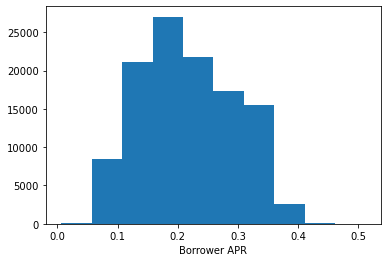

```python
plt.hist(data = df_loan, x = 'BorrowerAPR');
plt.xlabel('Borrower APR');
```

```python
# Describe the data
df_loan.BorrowerAPR.describe()
```

```
count    113937.000000
mean          0.218828
std           0.080355
min           0.006530
25%           0.156290
50%           0.209790
75%           0.283700
max           0.512290
Name: BorrowerAPR, dtype: float64
```

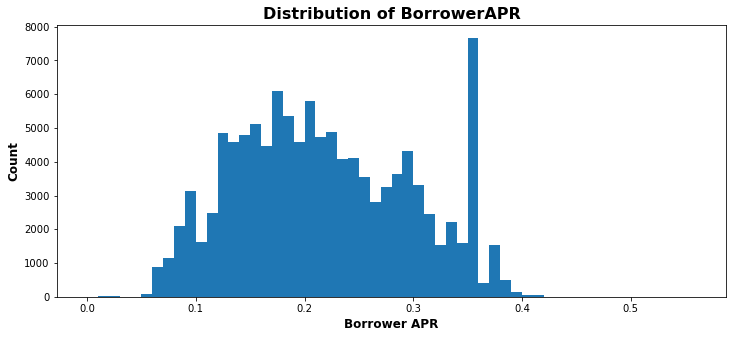

```python
# Plot of BorrowerAPR
# Set bin size
bins = np.arange(0, df_loan.BorrowerAPR.max()+0.05, 0.01)
# Set plot size
plt.figure(figsize=[12, 5])
# Plot the histogram of BorrowerAPR
plt.hist(data = df_loan, x = 'BorrowerAPR', bins = bins);
#xlabel
plt.xlabel('Borrower APR',weight = "bold", fontsize = 12);
#ylabel
plt.ylabel('Count',weight = "bold", fontsize = 12);
#title
plt.title('Distribution of BorrowerAPR', weight = "bold", fontsize= 16);
```

### Observation of BorrowerAPR

- The distribution of APR looks multimodal. A small peak centered at 0.1, a large peak centered at 0.2. There is also a small peak centered 0.3. Additionally, there is a very shape peak between 0.35 and 0.36. Only very few loans have APR greater than 0.43.

### Question

- What is the distribution of Original Loan amount?

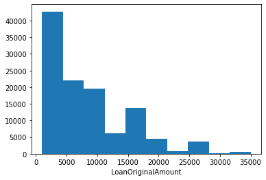

```python
plt.hist(data = df_loan, x = 'LoanOriginalAmount');
plt.xlabel('LoanOriginalAmount');
```

```python
# Transform the describe() to a scale of log10
# Documentation: [numpy `log10`](https://docs.scipy.org/doc/numpy/reference/generated/numpy.log10.html)

np.log10(df_loan.LoanOriginalAmount.describe())
```

```
count    5.056665
mean     3.921011
std      3.795588
min      3.000000
25%      3.602060
50%      3.812913
75%      4.079181
max      4.544068
Name: LoanOriginalAmount, dtype: float64
```

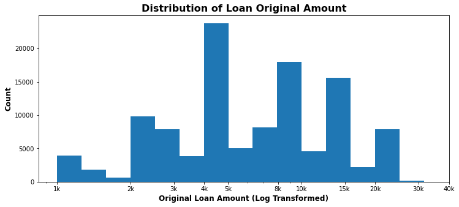

```python
# Define the plot size
plt.figure(figsize = [12, 5])


# Get the ticks for bins between [0 - maximum weight]
bins = 10 ** np.arange(3, 4.5+0.1, 0.1)

# Plot the histogram of Loanoriginal amount
plt.hist(data=df_loan, x='LoanOriginalAmount', bins=bins);

# The argument in the xscale() represents the axis scale type to apply.
# The possible values are: {"linear", "log", "symlog", "logit", ...}
plt.xscale('log')

# Apply x-ticks
plt.xticks([1e3, 2e3,3e3,4e3, 5e3, 8e3,1e4, 15e3,2e4,3e4,4e4], ['1k', '2k','3k','4k' ,'5k','8k', '10k','15k','20k','30k','40k'])
plt.xlabel('Original Loan Amount (Log Transformed)',weight = "bold", fontsize = 12);

plt.ylabel('Count',weight = "bold", fontsize = 12);

#title
plt.title('Distribution of Loan Original Amount', weight = "bold", fontsize = 16);
```

### Observation of LoanOriginalAmount

```python
df_loan.LoanOriginalAmount.value_counts()
```

```
4000     14333
15000    12407
10000    11106
5000      6990
2000      6067
         ...
7765         1
5652         1
9746         1
15889        1
12282        1
Name: LoanOriginalAmount, Length: 2468, dtype: int64
```

### Question

- What is the distribution of Debt to Income Ratio

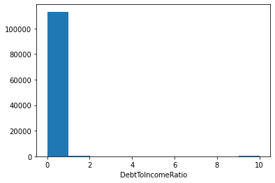

```python
plt.hist(data = df_loan, x = 'DebtToIncomeRatio');
plt.xlabel('DebtToIncomeRatio');
```

- There are outliers

```python
# Describe the data
df_loan.DebtToIncomeRatio.describe()
```

```
count    113937.000000
mean          0.275947
std           0.530643
min           0.000000
25%           0.150000
50%           0.230000
75%           0.310000
max          10.010000
Name: DebtToIncomeRatio, dtype: float64
```

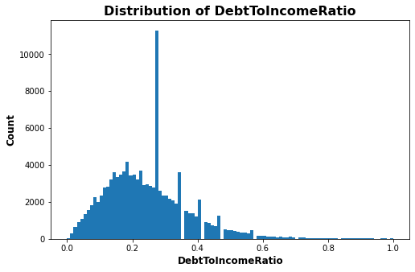

```python
bins = np.arange(0,1+0.01, 0.01)
plt.figure(figsize=[8, 5])
plt.hist(data = df_loan, x = 'DebtToIncomeRatio', bins = bins);

#xlabel
plt.xlabel('DebtToIncomeRatio',weight = "bold", fontsize = 12);
#ylabel
plt.ylabel('Count',weight = "bold", fontsize = 12);
#title
plt.title('Distribution of DebtToIncomeRatio', weight = "bold", fontsize= 16);
```

### Question

- What is the distribution of Term, Loanstatus, Prosperating, Incomerange, Employmenstatus, Listing year.

#### Define a countplot function

```python
def plotCountplot(x, figsize=(8,8)):
    #plot size
    plt.figure(figsize=figsize)
    #plot color
    base_color = sb.color_palette()[0]
    #Countplot
    sb.countplot(data = df_loan, x = x,color = base_color);
    #xlabel
    plt.xlabel(x, weight = "bold", fontsize = 12)
    #ylabel
    plt.ylabel('Count',weight = "bold", fontsize = 12)
    #title
    plt.title('Distribution of '+x, weight = "bold", fontsize = 16)
    plt.show()
```

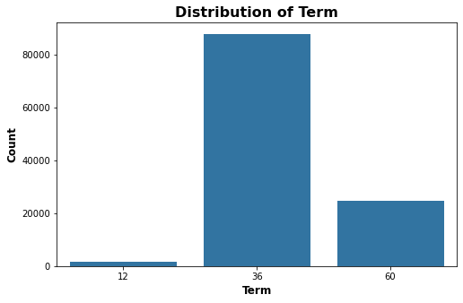

```python
# countplot for Term
plotCountplot("Term", figsize=(8,5))
```

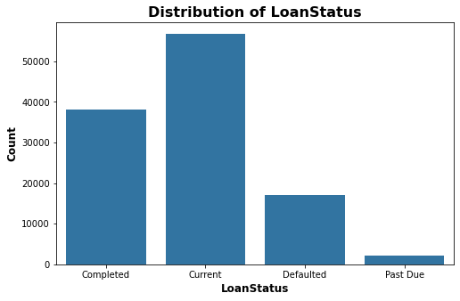

```python
# countplot for LoanStatus
plotCountplot("LoanStatus", figsize=(8,5))
```

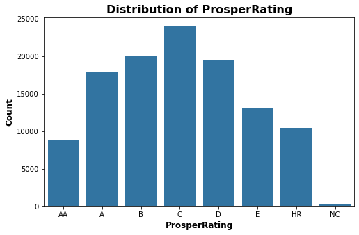

```python
# countplot for prosperrating
plotCountplot("ProsperRating", figsize=(8,5))
```

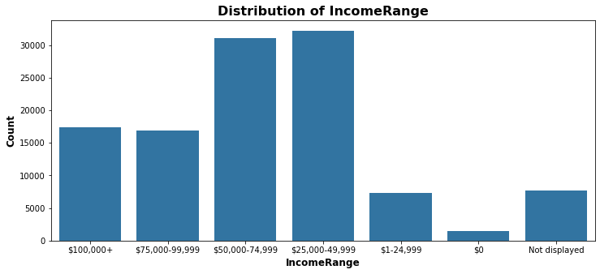

```python
# countplot for IncomeRange
plotCountplot("IncomeRange", figsize=(12,5))
```

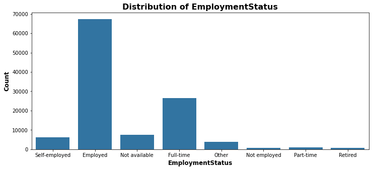

```python
# countplot for EmploymentStatus
plotCountplot("EmploymentStatus", figsize=(12,5))
```

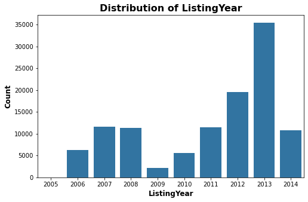

```python
# countplot for ListingYear
plotCountplot("ListingYear", figsize=(8,5))
```

### Question

What is the distribution of loan purpose?

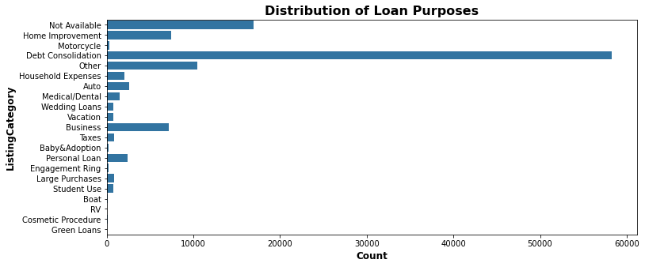

```python
#plot size
plt.figure(figsize=(12,5))
#plot color
base_color = sb.color_palette()[0]
#Countplot of ListingCategory
sb.countplot(data = df_loan, y= "ListingCategory" ,color = base_color);
#xlabel
plt.xlabel('Count', weight = "bold", fontsize = 12)
#ylabel
plt.ylabel('ListingCategory',weight = "bold", fontsize = 12);
#title
plt.title('Distribution of Loan Purposes', weight = "bold", fontsize = 16);
plt.show()
```

### Discuss the distribution(s) of your variable(s) of interest. Were there any unusual points? Did you need to perform any transformations?

> - The distribution of borrowers APR looks multimodal. Most of the values are at the range of 0.05 and 0.4. There are no unusual points and no need to perform any transformations.

### Of the features you investigated, were there any unusual distributions? Did you perform any operations on the data to tidy, adjust, or change the form of the data? If so, why did you do this?

> - Performed log transformation of LoanOriginalAmount
> - I removed outliers in DebtToIncomeRatio by setting the bins between 0 and 1 to get a better visualization of the distibution.
> - I defined a countplot function to avoid repetitive codes of visualisations.

## Bivariate Exploration

### Lets look at the Quantitative variables

### Question

What is the relationship between Original loan Amount and BorrowerAPR

```
the correlation between BorrowerAPR and Original Loan Amount is: -0.32285850125087506.
```

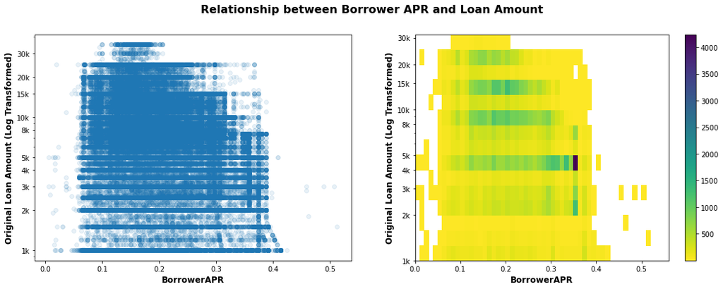

```python
# bivariate plot of LoanOriginalAmount vs. BorrowerAPR
# Scatter plot and hist2d
#plot size
plt.figure(figsize = [18, 6])

#PLOT ON LEFT
plt.subplot(1, 2, 1)
#Scatter plot of BorrowerAPR and LoanOriginalAmount
plt.scatter(data = df_loan, x = 'BorrowerAPR', y = 'LoanOriginalAmount', alpha = 1/10);
#xlabel
plt.xlabel('BorrowerAPR',weight = "bold", fontsize = 12)
#yscale
plt.yscale('log')
#yticks
plt.yticks([1e3, 2e3,3e3,4e3, 5e3, 8e3,1e4, 15e3,2e4,3e4], ['1k', '2k','3k','4k' ,'5k','8k', '10k','15k','20k','30k'])
#ylabel
plt.ylabel('Original Loan Amount (Log Transformed)',weight = "bold", fontsize = 12)


# PLOT ON RIGHT
plt.subplot(1, 2, 2)
#BorrowerAPR bin size
bins_x = np.arange(0, df_loan.BorrowerAPR.max()+0.05, 0.01)
#LoanOriginalAmount bin size
bins_y = 10 ** np.arange(3, 4.5+0.1, 0.1)
#hist2d of BorrowerAPR and LoanOriginalAmount
plt.hist2d(data = df_loan, x = 'BorrowerAPR', y = 'LoanOriginalAmount', cmin=0.5, cmap='viridis_r',  bins = [bins_x, bins_y])
#colorbar
plt.colorbar()
#yscale
plt.yscale('log')
#yticks
plt.yticks([1e3, 2e3,3e3,4e3, 5e3, 8e3,1e4, 15e3,2e4,3e4], ['1k', '2k','3k','4k' ,'5k','8k', '10k','15k','20k','30k'])
#xlabel
plt.xlabel('BorrowerAPR',weight = "bold", fontsize = 12)
#ylabel
plt.ylabel('Original Loan Amount (Log Transformed)',weight = "bold", fontsize = 12);
#title
plt.suptitle('Relationship between Borrower APR and Loan Amount', weight = "bold", fontsize = 16);
#correlation coff
corr = np.corrcoef(df_loan['BorrowerAPR'], df_loan['LoanOriginalAmount'])

print("the correlation between BorrowerAPR and Original Loan Amount is: {}.".format(corr[0,1]))
```

### Observation

a negative r means the increase in one variable tends to cause a decrease in another variable. The correlation coefficient of borrower APR and loan original amount is -0.323, the scatter plot also shows that these two variables are negatively correlated, which agrees with our hypothesis, that is the more the loan amount, the lower the APR.

### Question

What is the relationship between DebtToIncomeRatio and BorrowerAPR

```
the correlation between BorrowerAPR and DebtToIncomeRatio is: 0.053593949067441325.
```

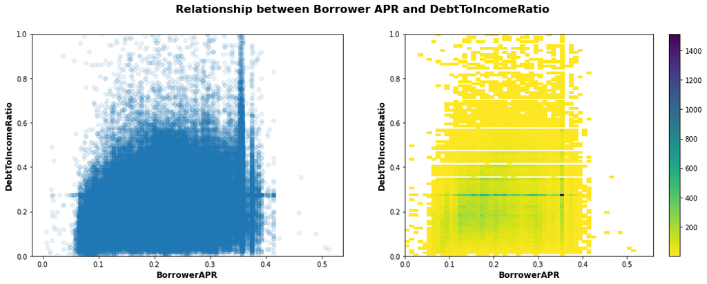

```python
# bivariate plot of DebtToIncomeRatio vs. BorrowerAPR
# Scatter plot

plt.figure(figsize = [18, 6])

#PLOT ON LEFT
plt.subplot(1, 2, 1)
plt.scatter(data = df_loan, x = 'BorrowerAPR', y = 'DebtToIncomeRatio', alpha = 1/10);
plt.ylim(0,1,0.01)
#xlabel
plt.xlabel('BorrowerAPR',weight = "bold", fontsize = 12)
#ylabel
plt.ylabel('DebtToIncomeRatio',weight = "bold", fontsize = 12);


# PLOT ON RIGHT
plt.subplot(1, 2, 2)
bins_x = np.arange(0, df_loan.BorrowerAPR.max()+0.05, 0.01)
bins_y = np.arange(0, df_loan.DebtToIncomeRatio.max()+0.01, 0.01)
plt.hist2d(data = df_loan, x = 'BorrowerAPR', y = 'DebtToIncomeRatio', cmin=0.5, cmap='viridis_r',  bins = [bins_x, bins_y])
plt.colorbar()
#ylim
plt.ylim(0,1,0.01)
#xlabel
plt.xlabel('BorrowerAPR',weight = "bold", fontsize = 12)
#ylabel
plt.ylabel('DebtToIncomeRatio',weight = "bold", fontsize = 12);
#title
plt.suptitle('Relationship between Borrower APR and DebtToIncomeRatio', weight = "bold", fontsize = 16);

corr = np.corrcoef(df_loan['BorrowerAPR'], df_loan["DebtToIncomeRatio"])
print("the correlation between BorrowerAPR and DebtToIncomeRatio is: {}.".format(corr[0,1]))
```

### Observation

There is no correlation between BorrowerAPR and DebtToIncomeRatio.

### Question

What is the relationship between Original loan Amount and DebtToIncomeRatio

```
the correlation between DebtToIncomeRatio and Original Loan Amount is: 0.009864434146790776.
```

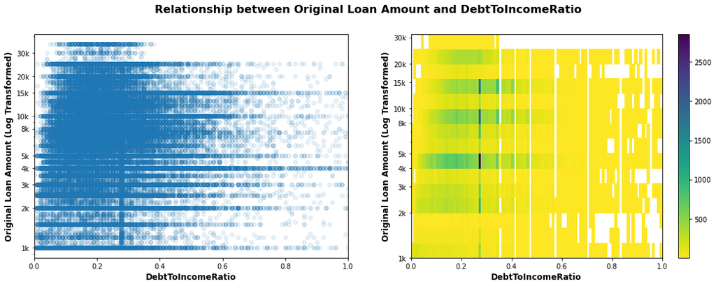

```python
# bivariate plot of LoanOriginalAmount vs. DebtToIncomeRatio
# Scatter plot

plt.figure(figsize = [18, 6])

#PLOT ON LEFT
plt.subplot(1, 2, 1)
plt.scatter(data = df_loan, x = 'DebtToIncomeRatio', y = 'LoanOriginalAmount', alpha = 1/10);
plt.xlim(0,1,0.01)
plt.yscale('log')
plt.yticks([1e3, 2e3,3e3,4e3, 5e3, 8e3,1e4, 15e3,2e4,3e4], ['1k', '2k','3k','4k' ,'5k','8k', '10k','15k','20k','30k'])
#xlabel
plt.xlabel('DebtToIncomeRatio',weight = "bold", fontsize = 12)
#ylabel
plt.ylabel('Original Loan Amount (Log Transformed)',weight = "bold", fontsize = 12);


# PLOT ON RIGHT
plt.subplot(1, 2, 2)
bins_x = np.arange(0,1+0.01, 0.01)
bins_y = 10 ** np.arange(3, 4.5+0.1, 0.1)
plt.hist2d(data = df_loan, x = 'DebtToIncomeRatio', y = 'LoanOriginalAmount', cmin=0.5, cmap='viridis_r',  bins = [bins_x, bins_y])
plt.colorbar()
plt.yscale('log')
plt.yticks([1e3, 2e3,3e3,4e3, 5e3, 8e3,1e4, 15e3,2e4,3e4], ['1k', '2k','3k','4k' ,'5k','8k', '10k','15k','20k','30k'])

#xlabel
plt.xlabel('DebtToIncomeRatio',weight = "bold", fontsize = 12)
#ylabel
plt.ylabel('Original Loan Amount (Log Transformed)',weight = "bold", fontsize = 12);

#title
plt.suptitle('Relationship between Original Loan Amount and DebtToIncomeRatio', weight = "bold", fontsize = 16);


corr = np.corrcoef(df_loan['DebtToIncomeRatio'], df_loan['LoanOriginalAmount'])
print("the correlation between DebtToIncomeRatio and Original Loan Amount is: {}.".format(corr[0,1]))
```

### Observation

There is no correlation between Original Loan Amount and DebtToIncomeRatio.

### Lets look at Quantitative and Qualitative Variables

### Question

What are the loan purposes with high average BorrowerAPR?

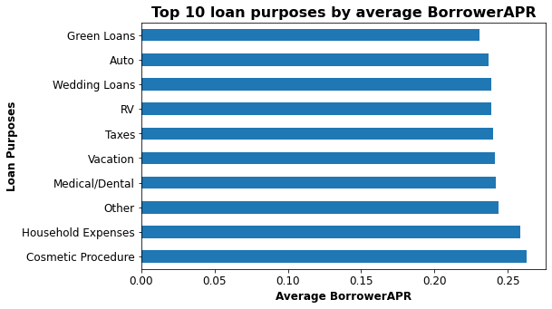

```python
# Extract top 10 loan purposes by average BorrowerAPR
#plot color
base_color = sb.color_palette()[0]
# 10 loan purposes grouped by BorrowerAPR mean
top_loan_mean = df_loan.groupby('ListingCategory')['BorrowerAPR'].mean().sort_values(ascending=False).nlargest(10)
#plot size
plt.figure(figsize=(8,5));
#title
plt.title("Top 10 loan purposes by average BorrowerAPR",weight = 'bold', fontsize=16);
#barchart
top_loan_mean.plot(kind='barh',fontsize=12,color=base_color);
#xlabel
plt.xlabel('Average BorrowerAPR', weight = 'bold', fontsize=12);
#ylabel
plt.ylabel('Loan Purposes', weight = 'bold', fontsize=12);
```

### Question

How does IncomeRange, ProsperRating, Term, EmploymentStatus, LoanStatus and Listing Year relate with BorrowerAPR?

#### Define a function to plot a boxplot and a violinplot showing how the features relate with BorrowAPR

```python
def plotboxandviolin1(x, figsize = (25,10)):
    #plot size
    plt.figure(figsize=figsize)
    #plot color
    base_color = sb.color_palette()[0]
    #plot on the left
    plt.subplot(1, 2, 1)
    #boxplot
    ax1 = sb.boxplot(data = df_loan, x = x , y = "BorrowerAPR", color = base_color, notch = True)
    #xlabel
    plt.xlabel(x, weight = 'bold',fontsize = 12)
    #ylabel
    plt.ylabel('BorrowerAPR',  weight = 'bold',fontsize = 12)

    #plot on the right
    plt.subplot(1, 2, 2)
    #violin plot
    sb.violinplot(data = df_loan, x = x, y = "BorrowerAPR", color = base_color, inner = "quartile")
    #get ylim for first plot
    plt.ylim(ax1.get_ylim())
    #xlabel
    plt.xlabel(x, weight = 'bold',fontsize = 12)
    #ylabel
    plt.ylabel('BorrowerAPR',  weight = 'bold',fontsize = 12)

    #title
    plt.suptitle("Boxplot and Violin plot between BorrowerAPR and "+ x ,weight = 'bold',fontsize = 16);
    plt.show()
```

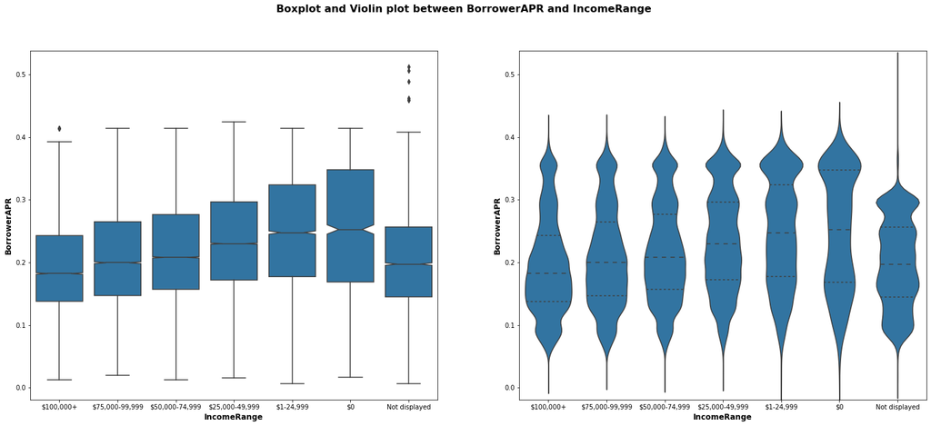

```python
plotboxandviolin1("IncomeRange")
```

### Observation

There is an inverse correlation between BorrowerAPR and IncomeRange. The Borrowers with Higher Salaries have low APRs.

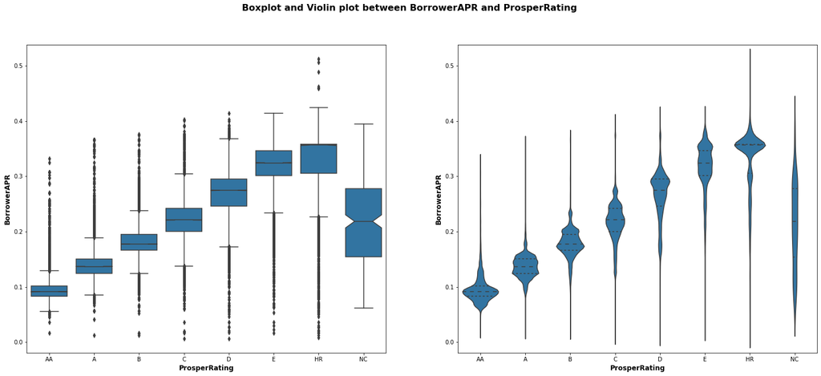

```python
plotboxandviolin1("ProsperRating")
```

### Observation

Lower BorrowerAPRs are attached with the least risky loans and higher BorrowerAPR attached to highly risked loans

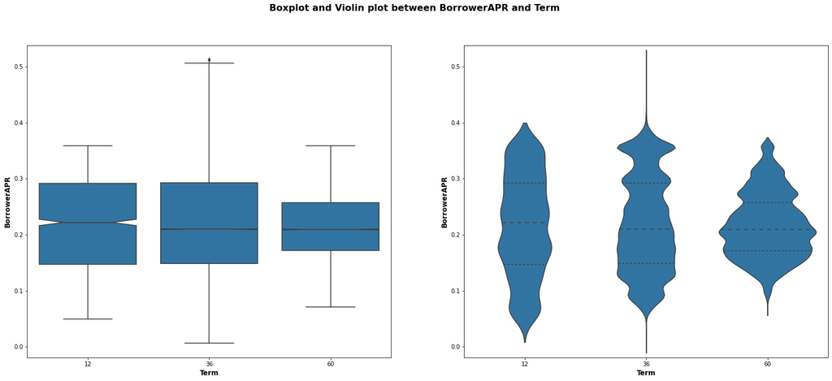

```python
plotboxandviolin1("Term")
```

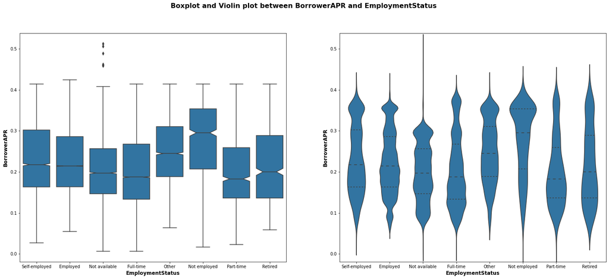

```python
plotboxandviolin1("EmploymentStatus")
```

### Observation

From the violinplot, More of the not employed employment status are attached with high BorrowerAPR.

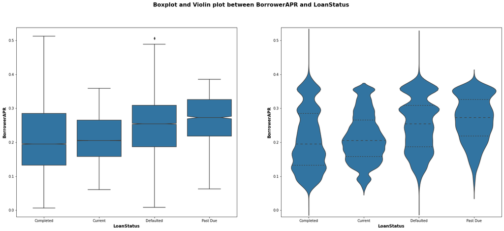

```python
plotboxandviolin1("LoanStatus")
```

### Observation

We can see that Defaulted and PastDue have higher BorrowerAPRs.

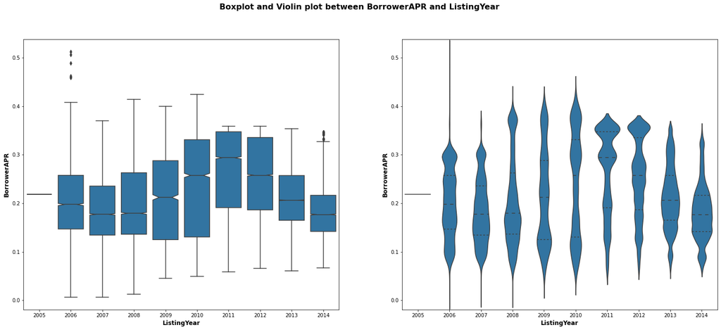

```python
plotboxandviolin1("ListingYear")
```

### Observation

We can see that there is BorrowerAPR improvement in recent years.

### Question

What are the loan purposes with high average loan amount?

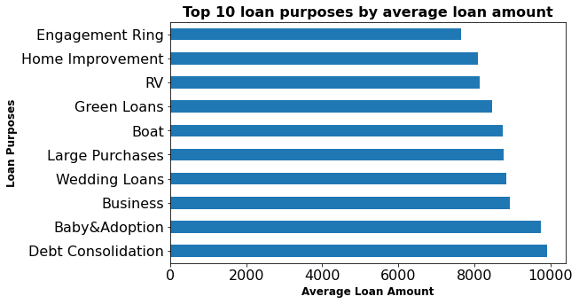

```python
# 10 top loan purposes groupedby highest average loan amount
top_loan_mean = df_loan.groupby('ListingCategory')['LoanOriginalAmount'].mean().sort_values(ascending=False).nlargest(10)
#plot size
plt.figure(figsize=(8,5));
#title
plt.title("Top 10 loan purposes by average loan amount", weight = 'bold',fontsize=16);
#barchart
top_loan_mean.plot(kind='barh',fontsize=16,color=base_color);
#xlabel
plt.xlabel('Average Loan Amount', weight = 'bold', fontsize=12);
#ylabel
plt.ylabel('Loan Purposes', weight = 'bold',fontsize=12);
```

### Observation

Debt Conslidation is still the highest in total value and average of Loan orginal amount

### Question

How does IncomeRange, ProsperRating, Term, EmploymentStatus, LoanStatus and Listing Year relate with Loan Orginal Amount?

#### Define a function to plot a boxplot and a violinplot showing how the features relate with Loan Orginal Amount.

```python
def plotboxandviolin2(x, figsize = (25,10)):
    #plot size
    plt.figure(figsize=figsize)
    #plot color
    base_color = sb.color_palette()[0]
    #plot on the left
    plt.subplot(1, 2, 1)
    #boxplot
    ax1 = sb.boxplot(data = df_loan, x = x , y = "LoanOriginalAmount", color = base_color, notch = True)
    #xlabel
    plt.xlabel(x, weight = 'bold',fontsize = 12)
    #ylabel
    plt.ylabel("LoanOriginalAmount",  weight = 'bold',fontsize = 12)
    plt.yscale('log')
    plt.yticks([1e3, 2e3,3e3,4e3, 5e3, 8e3,1e4, 15e3,2e4,3e4,4e4], ['1k', '2k','3k','4k' ,'5k','8k', '10k','15k','20k','30k','40k'])


    #plot on the right
    plt.subplot(1, 2, 2)
    #violin plot
    sb.violinplot(data = df_loan, x = x, y = "LoanOriginalAmount", color = base_color, inner = "quartile")
    #get ylim for first plot
    plt.ylim(ax1.get_ylim())
    #xlabel
    plt.xlabel(x, weight = 'bold',fontsize = 12)
    #ylabel
    plt.ylabel("LoanOriginalAmount",  weight = 'bold',fontsize = 12)
    plt.yscale('log')
    plt.yticks([1e3, 2e3,3e3,4e3, 5e3, 8e3,1e4, 15e3,2e4,3e4,4e4], ['1k', '2k','3k','4k' ,'5k','8k', '10k','15k','20k','30k','40k'])


    #title
    plt.suptitle("Boxplot and Violin plot between LoanOriginalAmount Original Loan Amount and "+ x ,weight = 'bold',fontsize = 16);
    plt.show()
```

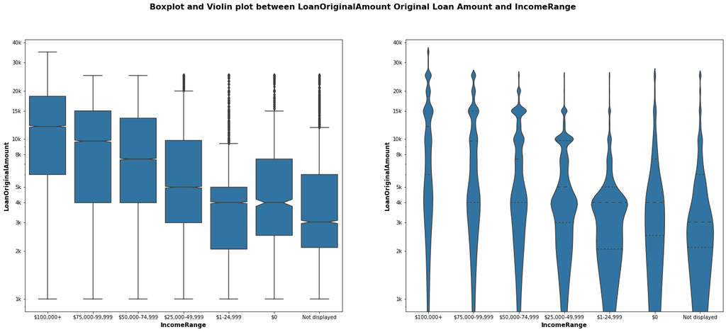

```python
plotboxandviolin2("IncomeRange")
```

### Observation

The loan original amount is positively correlated with the income, it makes sense since borrowers with more monthly income could loan more money.

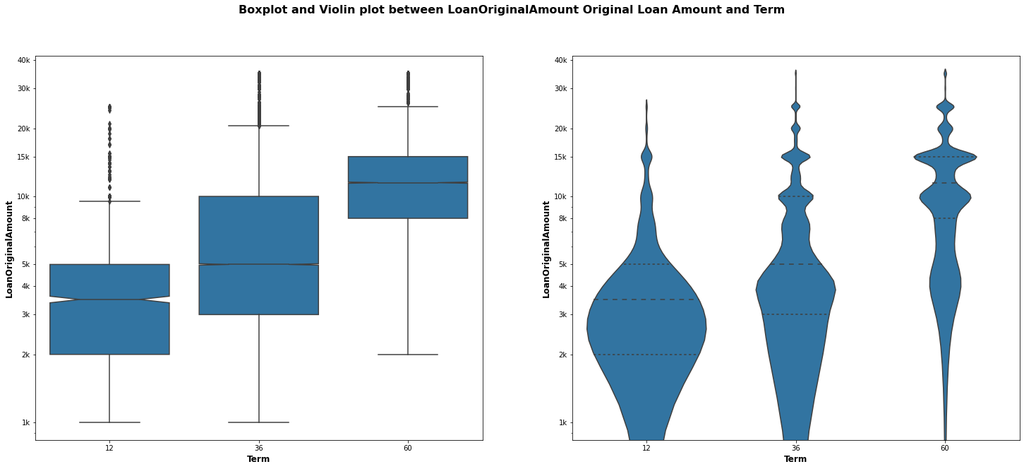

```python
plotboxandviolin2("Term")
```

### Observation

Shorter term loans is associated with smaller loans while longer term loans is associated with larger loans.

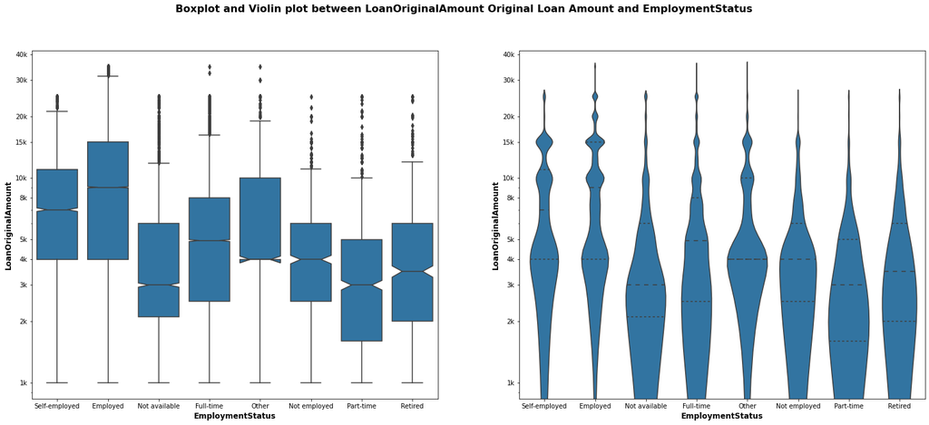

```python
plotboxandviolin2("EmploymentStatus")
```

### Observation

Working borrowers are granted higher loans.

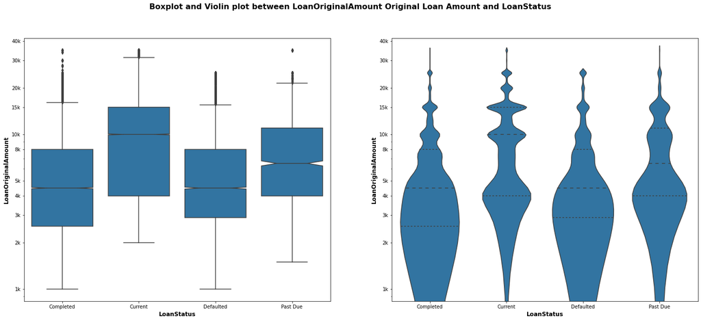

```python
plotboxandviolin2("LoanStatus")
```

### Observation

Most of the Chargedoff and Delinquent loans are less than 10k

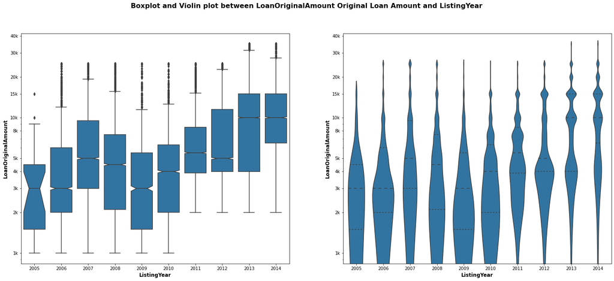

```python
plotboxandviolin2("ListingYear")
```

### Observation

Higher loans are borrowed in recent years.

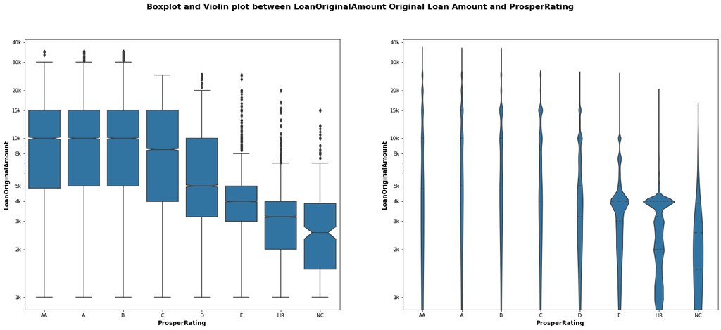

```python
plotboxandviolin2("ProsperRating")
```

### Observation

As the risk increases the amount borrowed also decreases

### Lets look at Qualitative Variables

```python
#### Define a function to plot a clusterbar
```

```python
def plotClusterBar(x, hue, figsize=(8,5)):
    #plot size
    plt.figure(figsize=figsize)
    #Clusterbar
    sb.countplot(x=x, hue=hue, data=df_loan)
    #xlabel
    plt.xlabel(x ,weight = "bold", fontsize = 12)
    #ylabel
    plt.ylabel('Count',weight = "bold", fontsize = 12)
    #title
    plt.title(x+" with respect to "+hue, weight='bold',fontsize=16)
    #legend
    plt.legend(title= hue ,loc = "center left", bbox_to_anchor = (1, 0.5));
    plt.show()
```

### Question

What is the relationship between ProsperRating and LoanStatus?

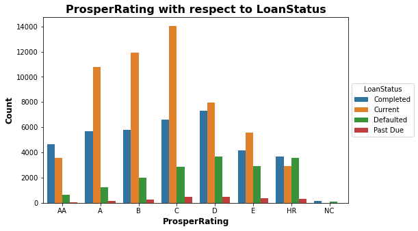

```python
plotClusterBar("ProsperRating","LoanStatus")
```

### Observation

What is the relationship between ListingYear and IncomeRange?

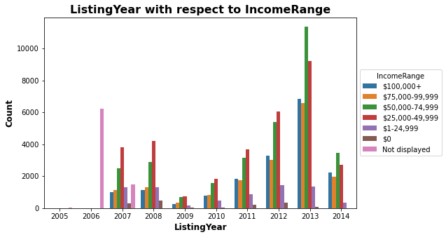

```python
plotClusterBar("ListingYear","IncomeRange")
```

### Observation

We can see that not displayed income ranges ends in 2007. This means the income range is an important feature in determining loan.

### Question

What is the relationship between LoanStatus and ListingCategory?

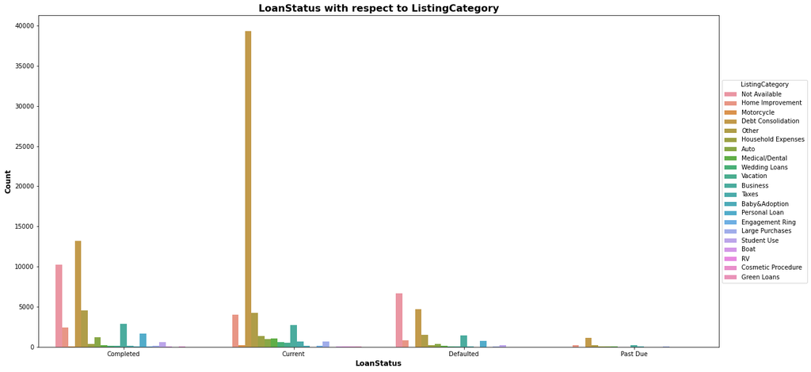

```python
plotClusterBar("LoanStatus","ListingCategory", figsize=(20,10))
```

### Question

What is the relationship between EmploymentStatus and ListingCatergory?

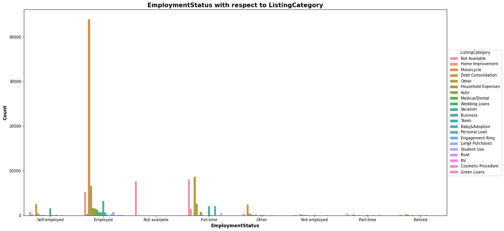

```python
plotClusterBar("EmploymentStatus","ListingCategory", figsize=(20,10))
```

### Observation

- Some Fulltime borrowers apply for loans without stating the purpose
- Borrowers without employment status are attached to not available loan purposes

### Question

What is the relationship between IncomeRange and ListingCategory?

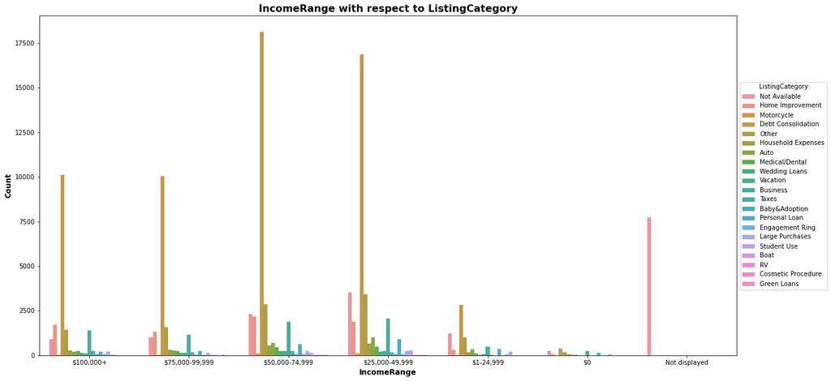

```python
plotClusterBar("IncomeRange","ListingCategory", figsize=(20,10))
```

### Observation

Not displayed IncomeRange are attached to not available loan purposes.

### Talk about some of the relationships you observed in this part of the investigation. How did the feature(s) of interest vary with other features in the dataset?

> There was a negative correlation between loan amount and borrower annual percentage rate. The more the borrower borrows, the lower the BorrowerAPR.

## Multivariate Exploration

### Question

How do all the features in the data set correlate?

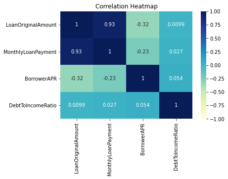

```python
# plot heat map to see correlation between features
loan_corrs = df_loan.corr()
sb.heatmap(loan_corrs,vmin=-1.0,vmax=1.0,annot=True, cmap="YlGnBu")
plt.title("Correlation Heatmap")
plt.show()
```

# Observation

- There is a positive correlation between Loan amount and monthly loan payment. The higher the loan, the high the monthly repayment
- There is a negative correlation between BorrowerAPR and monthly loan payment. The higher the BorrowerAPR , the lower the monthly repayment because it is a small loan
- There is a negative correlation between BorrowerAPR and loan amount. The higher the BorrowerAPR, the lower the loan amount.

### Lets take a sample of the population for the next plots to better see relationships.

```python
# create a sample of 1000
np.random.seed(2020)
samples = np.random.choice(a = df_loan.shape[0],size = 1000, replace = False)
loan_sample = df_loan.iloc[samples]
```

```python
#Sample Overview
print(loan_sample.shape)
loan_sample.info()
```

```
(1000, 14)
<class 'pandas.core.frame.DataFrame'>
Int64Index: 1000 entries, 69937 to 59402
Data columns (total 14 columns):
 #   Column               Non-Null Count  Dtype
---  ------               --------------  -----
 0   ListingKey           1000 non-null   object
 1   ListingCreationDate  1000 non-null   datetime64[ns]
 2   LoanOriginalAmount   1000 non-null   int64
 3   MonthlyLoanPayment   1000 non-null   float64
 4   Term                 1000 non-null   category
 5   LoanStatus           1000 non-null   category
 6   BorrowerAPR          1000 non-null   float64
 7   ListingCategory      1000 non-null   object
 8   BorrowerState        1000 non-null   object
 9   EmploymentStatus     1000 non-null   object
 10  DebtToIncomeRatio    1000 non-null   float64
 11  IncomeRange          1000 non-null   category
 12  ListingYear          1000 non-null   category
 13  ProsperRating        1000 non-null   category
dtypes: category(5), datetime64[ns](1), float64(3), int64(1), object(4)
memory usage: 84.4+ KB
```

#### Define a function to plot a Scatterplot showing how the features relate with Loan Orginal Amount and BorrowerAPR

```python
def plotfacetgrid(hue):
    #Facetgrid
    g = sb.FacetGrid(data = loan_sample, hue = hue, size = 7)
    #Scatterplot
    g.map(plt.scatter,'BorrowerAPR', 'LoanOriginalAmount')
    #yscale
    g.set(yscale = 'log')
    #ylabel
    plt.ylabel('LoanOriginalAmount (Log Transformed)',weight = "bold", fontsize = 12)
    #xlabel
    plt.xlabel('BorrowerAPR',weight = "bold", fontsize = 12)
    #legend
    plt.legend(title= hue , loc = "center left", bbox_to_anchor = (1, 0.5))
    #title
    plt.title('BorrowerAPR and LoanOrginal Amount for '+hue, weight = "bold", fontsize = 16)
    #yticks
    plt.yticks([1e3, 2e3,3e3,4e3, 5e3, 8e3,1e4, 15e3,2e4,3e4,4e4], ['1k', '2k','3k','4k' ,'5k','8k', '10k','15k','20k','30k','40k']);
```

### Question

What is the relationship between BorrowerAPR, LoanOriginalAmount and ProsperRating?

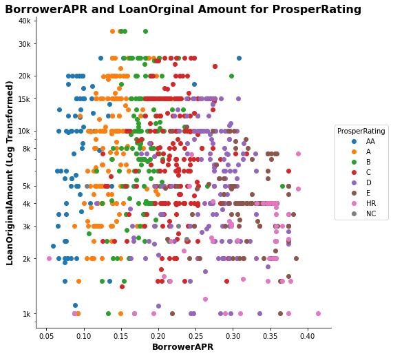

```python
plotfacetgrid('ProsperRating')
```

### Observation

- The ProperRatings is well distributed across BorrowerAPR and Loan Amount.
- The loans with good ratings have low BorrowerAPR.
- HR and NC ratings are not more than 10k in loan amount

### Question

What is the relationship between BorrowerAPR, LoanOriginalAmount and Term?

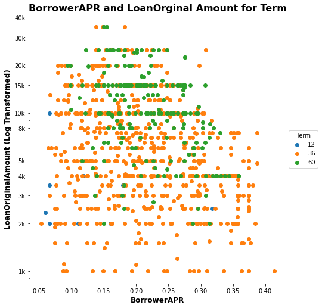

```python
plotfacetgrid('Term')
```

### Observation

- short term loans have better BorrowerAPR.
- longer term loans are attached to higher loans

### Question

What is the relationship between BorrowerAPR, LoanOriginalAmount and LoanStatus?

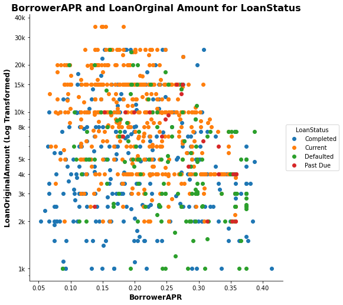

```python
plotfacetgrid('LoanStatus')
```

### Observations

- The current loan status have high loan value

### Question

What is the relationship between BorrowerAPR, LoanOriginalAmount and IncomeRange?

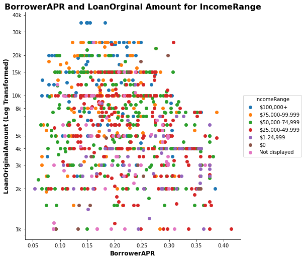

```python
plotfacetgrid('IncomeRange')
```

### Observation

- IncomeRange is well distributed. High incomes earners can borrow more

### Question

What is the relationship between ListingYear, LoanOriginalAmount and LoanStatus?

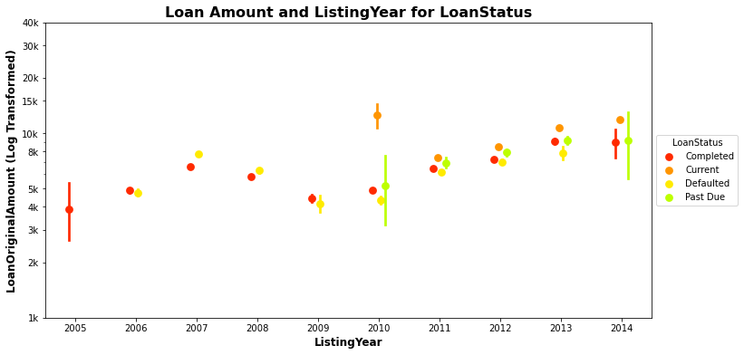

```python
plt.figure(figsize = [12,6])

ax = sb.pointplot(data = df_loan, x = 'ListingYear', y = 'LoanOriginalAmount', hue = 'LoanStatus', dodge = 0.2, linestyles="",
                  palette="prism")
#title
plt.title('Loan Amount and ListingYear for LoanStatus',weight = "bold", fontsize = 16);
#legend
plt.legend(title='LoanStatus',loc = "center left", bbox_to_anchor = (1, 0.5))
#xlabel
plt.xlabel('ListingYear',weight = "bold", fontsize = 12)
#ylabel
plt.ylabel('LoanOriginalAmount (Log Transformed)',weight = "bold", fontsize = 12)
#yscale
plt.yscale('log')
#yticks
plt.yticks([1e3, 2e3,3e3,4e3, 5e3, 8e3,1e4, 15e3,2e4,3e4,4e4], ['1k', '2k','3k','4k' ,'5k','8k', '10k','15k','20k','30k','40k']);
plt.xticks(rotation= 0)
plt.show();
```

### Observation

- There are no chargedoff loans in 2014

### Question

What is the relationship between BorrowerAPR, ListingYear and LoanStatus?

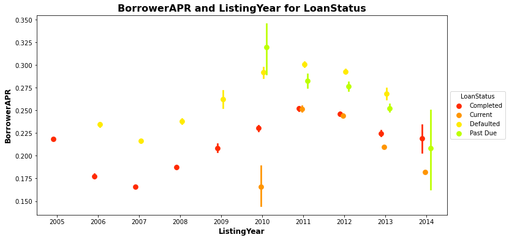

```python
plt.figure(figsize = [12,6])

ax = sb.pointplot(data = df_loan, x = 'ListingYear', y = 'BorrowerAPR', hue = 'LoanStatus', dodge = 0.2, linestyles="",
                  palette="prism")
#xlabel
plt.xlabel('ListingYear',weight = "bold", fontsize = 12)
#ylabel
plt.ylabel('BorrowerAPR',weight = "bold", fontsize = 12)
#title
plt.title('BorrowerAPR and ListingYear for LoanStatus', weight = "bold", fontsize = 16);
#legend
plt.legend(title = 'LoanStatus',loc = "center left", bbox_to_anchor = (1, 0.5))
plt.xticks(rotation= 0)
plt.show();
```

### Question

What is the relationship between BorrowerAPR, ProsperRating and LoanStatus?

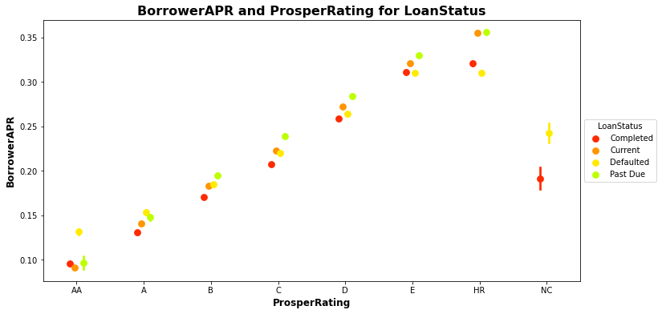

```python
#plot size
plt.figure(figsize = [12,6])
#Pointplot of BorrowerAPR, ProsperRating and LoanStatus
ax = sb.pointplot(data = df_loan, x = 'ProsperRating', y = 'BorrowerAPR', hue = 'LoanStatus', dodge = 0.2, linestyles="",
                  palette="prism")
#xlabel
plt.xlabel('ProsperRating',weight = "bold", fontsize = 12)
#ylabel
plt.ylabel('BorrowerAPR',weight = "bold", fontsize = 12)
#title
plt.title('BorrowerAPR and ProsperRating for LoanStatus', weight = "bold", fontsize = 16);
#legend
plt.legend(title = 'LoanStatus',loc = "center left", bbox_to_anchor = (1, 0.5))
plt.xticks(rotation= 0)
plt.show();
```

### Observation

- Theis clearly shows a positive correlation between BorrowerAPR and ProsperRating.

### Question

What is the relationship between ProsperRating, LoanOriginalAmount and LoanStatus?

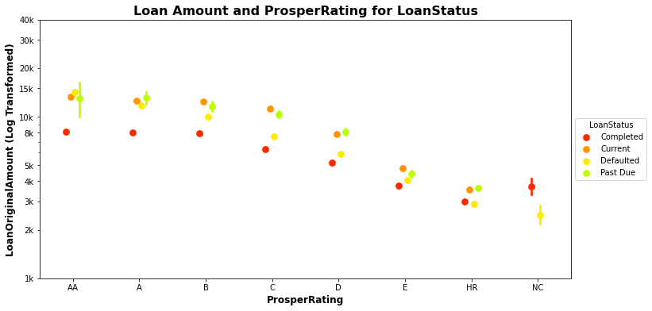

```python
#plotsize
plt.figure(figsize = [12,6])
#pointplot of ProsperRating, LoanOriginalAmount and LoanStatus
ax = sb.pointplot(data = df_loan, x = 'ProsperRating', y = 'LoanOriginalAmount', hue = 'LoanStatus', dodge = 0.2, linestyles="",
                  palette="prism")
#title
plt.title('Loan Amount and ProsperRating for LoanStatus',weight = "bold", fontsize = 16);
#legend
plt.legend(title='LoanStatus',loc = "center left", bbox_to_anchor = (1, 0.5))
#xlabel
plt.xlabel('ProsperRating',weight = "bold", fontsize = 12)
#ylabel
plt.ylabel('LoanOriginalAmount (Log Transformed)',weight = "bold", fontsize = 12)
#yscale
plt.yscale('log')
#yticks
plt.yticks([1e3, 2e3,3e3,4e3, 5e3, 8e3,1e4, 15e3,2e4,3e4,4e4], ['1k', '2k','3k','4k' ,'5k','8k', '10k','15k','20k','30k','40k']);
plt.xticks(rotation= 0)
plt.show();
```

### Observation

- This clearly shows a negative relationship between LoanOriginalAmount and ProsperRating.

### Talk about some of the relationships you observed in this part of the investigation. Were there features that strengthened each other in terms of looking at your feature(s) of interest?

> - The ProperRatings is well distributed across BorrowerAPR and Loan Amount.
> - shorter term loans have better BorrowerAPR and low loan amount while longer term loans are attached to higher loan amount and the borrowerAPR is well distributed.
> - High income earners have good borrowerAPR and can borrow more.

### Were there any interesting or surprising interactions between features?

> - ProsperRating to see if the risk management system. As shown on the plot, only a few borrowers have defaulted loans with Prosper Rating of AA.
> - High income individuals borrow more for debt consolidation and complete their loans.

## Conclusions

> The data exploration has been well documented, with the emphasis on the main features and their interactions with other features.
> - The first step before conducting any data analysis is to understand the meaning of each variable.
> - After reading through the descriptions and definitions, I chose ‘BorrowerAPR’ and 'LoanOriginalAmount' as my main features.
> - I created a sub dataset which includes 14 variables and 113,937 observations selected from the given that dataset
> - I made use of histogram and countplot to show the distribution of the univariate analysis, scatterplots for quantitative bivariate analysis, boxplots and violinplots for quantitative and qualitative bivariate analysis, Clusterbars for qualitative bivariate analysis, Facetgrid and Pointplots for multivariate analysis
> - I further studied features that have stronger correlations with the main features.
> - I extracted a sample of 1000 observations for some multivariate analysis to get a clearer picture.
> - I defined plot functions to avoid repetitive codes.
> - After analysing all the related features available in the dataset, we have come to an end, deducing the main driving features for the Prosper Loan are BorrowerAPR, LoanOriginalAmount, Term, ProsperRating, IncomeRange and ListingCategory